# HW 04: Alumni jobs

Author

In this homework, you’ll use simple linear regression to analyze the relationship between the median early career salary and percent of alumni who perceive their job as making the world a better place for colleges and universities in the United States.

# Learning goals

By the end of the homework you will be able to…

- assess model conditions for simple linear regression.
- calculate and interpret predicted values from the model.
- assess model fit using $R^2$ and RMSE

# Getting started

- Go to [RStudio](https://rstudio.collegeofidaho.edu) and login with your College of Idaho Email and Password.
- Make a subfolder in your `hw` directory to store this homework.
- Log into [Canvas](https://cofi.instructure.com/courses/17093/assignments/202862), navigate to Homework 4 and upload the `hw-04.qmd` and `alumni-salaries.csv` file into the folder your just made.

# Packages

We’ll use the following packages in this homework.

```r
library(tidyverse)
library(broom)
library(yardstick)
library(ggformula)
library(knitr)
library(patchwork)
# add more packages as needed
```

# Data: Alumni jobs

Today’s data set is part of the [TidyTuesday College tuition, diversity, and pay](https://github.com/rfordatascience/tidytuesday/blob/master/data/2020/2020-03-10/readme.md).

The information in this data set was collected from the [PayScale College Salary Report](https://www.payscale.com/college-salary-report/bachelors).

| variable | class | description |
| --- | --- | --- |
| rank | double | Potential salary rank within state |
| name | character | Name of school |
| state_name | character | state name |
| early_career_pay | double | Median salary for alumni with 0 - 5 years experience (in US dollars) |
| mid_career_pay | double | Median salary for alumni with 0 - 5 years experience (in US dollars) |
| make_world_better_percent | double | Percent of alumni who think they are making the world a better place |
| stem_percent | double | Percent of degrees awarded in science, technology, engineering, or math subjects |

```r
alumni <- read_csv("~/MAT-212/hw/hw04/alumni-salaries.csv")
glimpse(alumni)
```

```
Rows: 572
Columns: 7
$ rank                      <dbl> 1, 2, 4, 5, 6, 8, 9, 11, 12, 13, 14, 15, 15,…
$ name                      <chr> "Auburn University", "University of Alabama …
$ state_name                <chr> "Alabama", "Alabama", "Alabama", "Alabama", …
$ early_career_pay          <dbl> 54400, 57500, 54500, 48400, 46600, 48600, 47…
$ mid_career_pay            <dbl> 104500, 103900, 93500, 90500, 89100, 87200, …
$ make_world_better_percent <dbl> 51, 59, 61, 52, 53, 57, 56, 60, 61, 61, 69, …
$ stem_percent              <dbl> 31, 45, 30, 3, 12, 17, 17, 8, 7, 12, 14, 16,…
```

# Exercises

Is there a relationship the typical early career pay for alumni and the percent of alumni who receive a STEM degree? To answer this question, we will use regression to predict the early career pay using the percent of STEM degrees.

## Exercise 1

Fit a linear model that can be used to predict the typical early career pay based on the percent of STEM degrees. Display the model output using 3 digits for numerical values.

```r
alumni_fit <- lm(early_career_pay~stem_percent, data = alumni)
tidy(alumni_fit) |>
  kable(digits = 3)
```

| term | estimate | std.error | statistic | p.value |
| --- | --- | --- | --- | --- |
| (Intercept) | 45433.879 | 384.005 | 118.316 | 0 |
| stem_percent | 334.953 | 17.132 | 19.552 | 0 |

## Exercise 2

Calculate the predicted values and residuals from your model and save these results in a data frame. Print the first five rows of the new data frame.

```r
aug_alumni <- augment(alumni_fit)
#aug_alumni

head(aug_alumni, 5)
```

```
# A tibble: 5 × 8
  early_career_pay stem_percent .fitted .resid    .hat .sigma .cooksd .std.resid
             <dbl>        <dbl>   <dbl>  <dbl>   <dbl>  <dbl>   <dbl>      <dbl>
1            54400           31  55817. -1417. 0.00335  6007. 9.41e-5     -0.237
2            57500           45  60507. -3007. 0.00815  6006. 1.04e-3     -0.503
3            54500           30  55482.  -982. 0.00313  6007. 4.22e-5     -0.164
4            48400            3  46439.  1961. 0.00334  6006. 1.79e-4      0.327
5            46600           12  49453. -2853. 0.00195  6006. 2.21e-4     -0.476
```

## Exercise 3

Before using the model for prediction, let’s check the model conditions. To figure out how to do so, we type the following prompt into ChatGPT (“an AI powered language model”) *“How do you check the model conditions for simple linear regression?”*

The response from ChatGPT shown below would receive partial credit. For each condition, state whether it is correct or incorrect/incomplete. If it incorrect/incomplete, state what is wrong or missing, then write the correct response. Please put all answers after the ChatGPT text.

> *In simple linear regression, you’re trying to establish a linear relationship between two variables: a dependent variable (Y) and an independent variable (X). The model conditions or assumptions for simple linear regression are important to check to ensure that your model is valid and reliable. Here are the key assumptions and how to check them:*

> *1. Linearity Assumption:*
> - *Assumption: The relationship between the independent variable (X) and the dependent variable (Y) is linear.*
> - *How to Check: Create a scatterplot of Y against X. If the points roughly form a straight line, the linearity assumption is likely met.*

>   Yes, i think the answer is complete. It is because you check the linearity by plotting the model and sort of filtering. If it forms a linear projection, the strength of linearity will determine the strength in their relationship.

> *2. Independence Assumption:*
> - *Assumption: The residuals (the differences between observed Y and predicted Y) are independent of each other.*
> - *How to Check: Plot the residuals against the independent variable (X) or the predicted values. Look for patterns or trends in the residuals. There should be no clear structure or autocorrelation in the residuals.*

>   It is wrong because we can assume the independence straight by looking at the data and how they were collected. We can check independence through cluster effects, temporal correlation and other methods. It may not be wrong but we have an easier way which is just to look up at the data.

> *3. Homoscedasticity [Constant variance] Assumption:*
> - *Assumption: The variance of the residuals is constant across all levels of the independent variable.*
> - *How to Check: Plot the residuals against the predicted values or the independent variable (X). The spread of the residuals should remain roughly constant across the range of X.*

>   Yes, it is right but incomplete. Its just that in graph we observe residuals as well. the spread should remain constant.

> *4. Normality Assumption:*
> - *Assumption: The residuals follow a normal distribution.*
> - *How to Check: Create a histogram or a normal probability plot (Q-Q plot) of the residuals. If the residuals are approximately normally distributed, they should follow a bell-shaped curve in the histogram and lie along a straight line in the Q-Q plot.*

>   It is right. The histogram should follow the bell shaped curve around 0. I am not sure it the ChatGPT generated answer meant straight diagonal line or straight horizontal. But if it meant horizontal line then it would be wrong because in QQ plot, we look for a straight diagonal line.

> *It’s important to note that these assumptions may not always hold perfectly in real-world data, and minor violations may not necessarily invalidate your model. However, if you detect significant violations of these assumptions, you may need to consider alternative modeling techniques or transformations of your data to address the issues.*

## Exercise 4

Determine to what extent the model conditions hold. Briefly describe how that will impact any statistical inference.

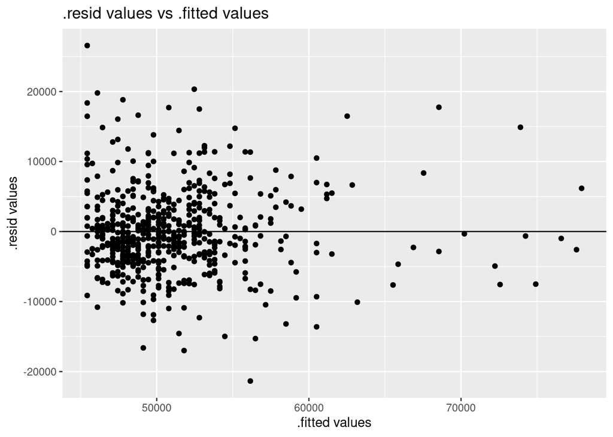

```r
gf_point(.resid ~ .fitted, data = aug_alumni) |>
  gf_hline(yintercept = 0) |>
  gf_labs(
    title = ".resid values vs .fitted values",
    x = ".fitted values", y = ".resid values"
  )
```

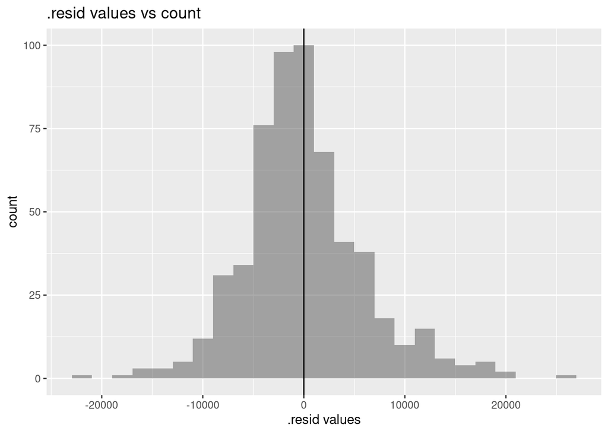

```r
gf_histogram(~ .resid, data = aug_alumni) |>
  gf_vline(xintercept = 0) |>
  gf_labs(
    title = ".resid values vs count",
    x = ".resid values", y = "count"
  )
```

this also looks like a normal distribution. It is bell shaped and centered around 0. we do have some residual around tails but that should not be enough to say that this is not a normal distribution.

## Exercise 5

- 31 percent of the alumni at Johns Hopkins University received a STEM degree. Calculate the predicted early career pay at this university and the appropriate 95% interval. Interpret the interval in the context of the data.

  ```r
  predict_pay <- tibble(stem_percent = 31)
  predict(alumni_fit, newdata = predict_pay, interval = "prediction", level = 0.95)
  ```

  ```
         fit      lwr      upr
  1 55817.43 44009.75 67625.11
  ```

  It means that it is 95% confident that the early career pay at this univeristy with 31% stem degree falls between 44009.75 to 67625.11
- The actual early career pay at this university is $67,200. Is this what you expected based on your analysis? Briefly explain your reasoning.

  Yes, it falls within the fall range. It is near the upper bound of the interval.

## Exercise 6

Next, let’s consider how well the model fits the relationship between the early career pay and percent with a STEM degree.

- Calculate $R^2$ and interpret it in the context of the data.

  ```r
  rsq(aug_alumni, truth = early_career_pay, estimate = .fitted)
  ```

  ```
  # A tibble: 1 × 3
    .metric .estimator .estimate
    <chr>   <chr>          <dbl>
  1 rsq     standard       0.401
  ```

  It is not a good predictor because it it has $R^2$ of 0.4. it ranges from 0-1 where 1 is a very good predictor. also the score also means that it correctly predicts 40.14% of the early career pay.
- Calculate RMSE and interpret it in the context of the data.

  ```r
  # Had to call the function specifically because rmse was not recognizing truht and estimate
  yardstick::rmse(aug_alumni, truth = early_career_pay, estimate = .fitted)
  ```

  ```
  # A tibble: 1 × 3
    .metric .estimator .estimate
    <chr>   <chr>          <dbl>
  1 rmse    standard       5991.
  ```

For RMSE, numbers closer to 0 are considered to be a good projector but since the number is no where close to zero, we can conlcude by saying that there in not a good relation between two variables.

## Exercise 7

Do you think the model is useful for understanding and predicting the typical early career pay for alumni at a university? Briefly explain your reasoning.

I will not say that it is useful for understanding and predicting the typical early career pay because $R^2$ is only predicting 40% of the estimates and also there is a lot of variability in RMSE showing lack in precision.

## Exercise 8

Fit another model which predicts the typical early career pay using only the percentage of alumni that believe their career will make the world a better place.

- Neatly display this model with 3 digits.
- Which model do you think is better - this model or the model fit in Exercise 1? Explain your response showing any analysis used to make the decision.

  ```r
  better_world_fit <- lm(early_career_pay ~ make_world_better_percent, data = alumni)
  tidy(better_world_fit) |>
    kable(digits = 3)
  ```

  | term | estimate | std.error | statistic | p.value |
  | --- | --- | --- | --- | --- |
  | (Intercept) | 65075.354 | 1920.165 | 33.891 | 0 |
  | make_world_better_percent | -259.286 | 35.201 | -7.366 | 0 |

I will say the model in exercise 1 was more useful or is better than this one because, it is simpler to understand. In general, it is easier for us to understand the relation between higher pay and if the student is a STEM major or not. Also, second model has a negative slope which could be tough in representing some scenarios.

Both of them have same P value but there is a big gap in standard error between the two of them where the model from exercise one gives us a lower standard error.

# Submission

**Warning**

Before you wrap up the assignment, make sure you render your HTML file and it appears how you want it to.

Upload the qmd and HTML files to Canvas.

# Grading (17pts)

| Component | Points |
| --- | --- |
| Ex 1 | 1 |
| Ex 2 | 1 |
| Ex 3 | 1 |
| Ex 4 | 3 |
| Ex 5 | 2 |
| Ex 6 | 4 |
| Ex 7 | 1 |
| Ex 8 | 2 |
| Grammar & Writing | 1[^1] |
| Workflow & formatting | 1[^2] |

## Footnotes

[^1]: The “Grammar & Writing” grade is decided based on your grammar and writing. This is typically decided by choosing one of the questions and assessing the writing.
[^2]: The “Workflow & formatting” grade is to assess the reproducible workflow and document format. This includes having a neatly organized document with readable code and your name and the date in the YAML.